# Milestones_initial_attempt

7. Do certain months consistently have more opioid shipments during the period of 2006-2012 relative to the other months?
8. Are there certain months that stay at a certain number of shipments consistently through-out the 2006 to 2012 period?
9. Do the winter months or the summer months have consistently more opioid shipments? If so in which years?
10. Is there a 12 month trend for opioid shipments that is consistent through-out the years 2006-2012?
11. Are there any abnormal or large spikes in the number of opioid shipments for a certain month?
12. (Conintinuation of last question) Are these spikes consitent in the month that it’s happening or is it a different month depending on the year?

PILLS BY MONTH LOGAN COUNTY WEST VIRGINIA Year 2006

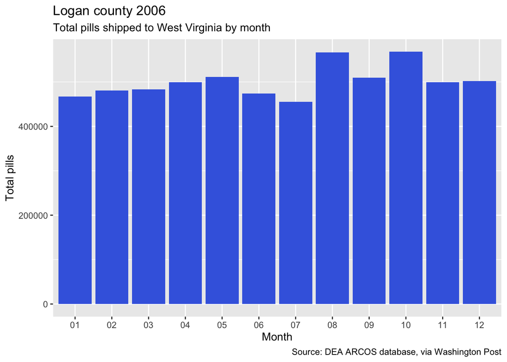

```r
west_virginia <- summarized_county_monthly(county="Logan", state="WV", key = key) %>%
clean_names()  %>%
filter(buyer_state == "WV", year=="2006")

ggplot(west_virginia) +
  geom_bar(stat="identity", aes(month, dosage_unit), fill="royal blue") +
  labs(x="Month", y="Total pills", title="Logan county 2006", subtitle = "Total pills shipped to West Virginia by month", caption = "Source: DEA ARCOS database, via Washington Post")
```

```r
  options(scipen=999)
```

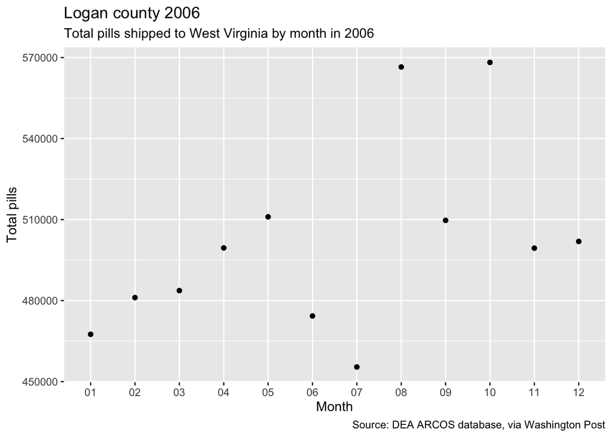

```r
west_virginia <- summarized_county_monthly(county="Logan", state="WV", key = key) %>%
clean_names()  %>%
filter(buyer_state == "WV", year=="2006")

ggplot(west_virginia) +
  geom_point(aes(month, dosage_unit)) +
 labs(x="Month", y="Total pills", title="Logan county 2006", subtitle = "Total pills shipped to West Virginia by month in 2006", caption = "Source: DEA ARCOS database, via Washington Post")
```

Year 2007

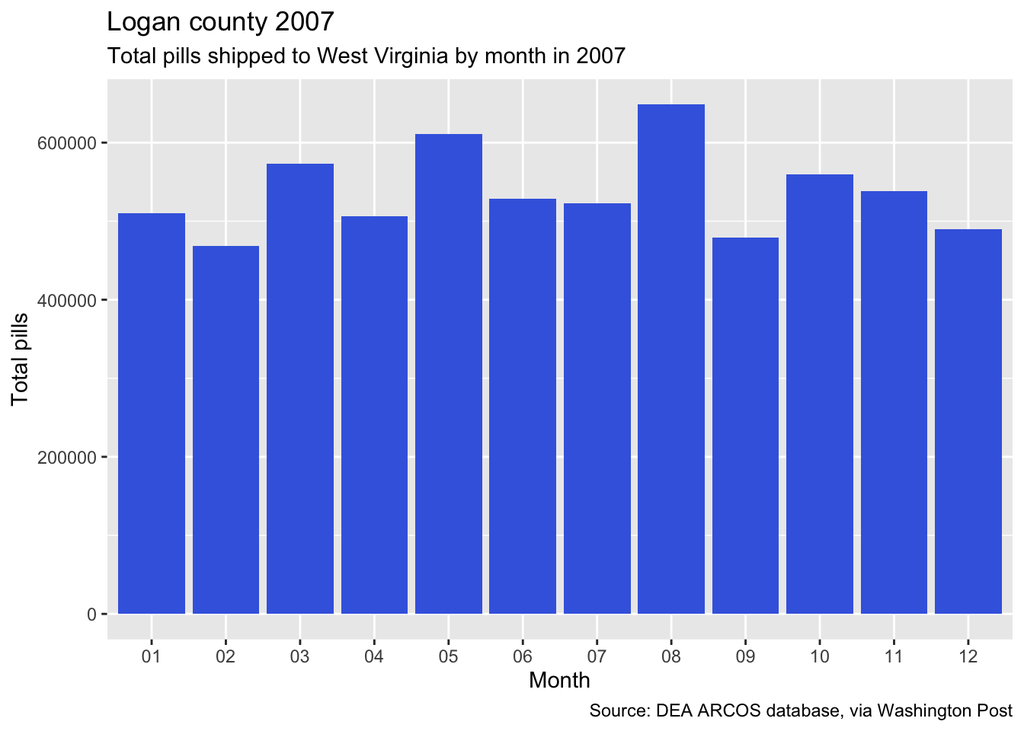

```r
west_virginia <- summarized_county_monthly(county="Logan", state="WV", key = key) %>%
clean_names()  %>%
filter(buyer_state == "WV", year=="2007")

ggplot(west_virginia) +
  geom_bar(stat="identity", aes(month, dosage_unit), fill="royal blue") +
  labs(x="Month", y="Total pills", title="Logan county 2007", subtitle = "Total pills shipped to West Virginia by month in 2007", caption = "Source: DEA ARCOS database, via Washington Post")
```

```r
  options(scipen=999)
```

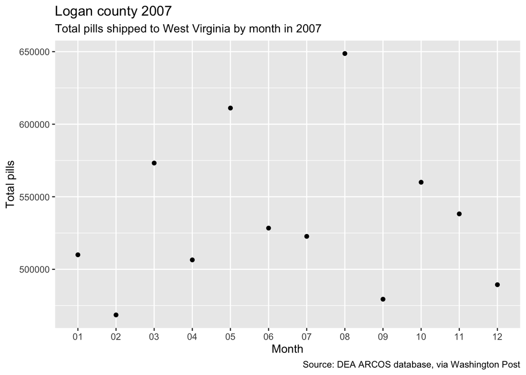

```r
west_virginia <- summarized_county_monthly(county="Logan", state="WV", key = key) %>%
clean_names()  %>%
filter(buyer_state == "WV", year=="2007")

ggplot(west_virginia) +
  geom_point(aes(month, dosage_unit)) +
 labs(x="Month", y="Total pills", title="Logan county 2007", subtitle = "Total pills shipped to West Virginia by month in 2007", caption = "Source: DEA ARCOS database, via Washington Post")
```

Year 2008

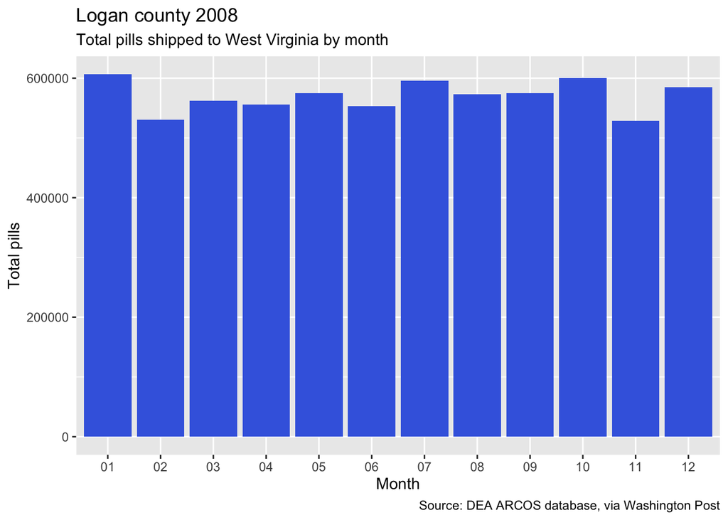

```r
west_virginia <- summarized_county_monthly(county="Logan", state="WV", key = key) %>%
clean_names()  %>%
filter(buyer_state == "WV", year=="2008")

ggplot(west_virginia) +
  geom_bar(stat="identity", aes(month, dosage_unit), fill="royal blue") +
  labs(x="Month", y="Total pills", title="Logan county 2008", subtitle = "Total pills shipped to West Virginia by month", caption = "Source: DEA ARCOS database, via Washington Post")
```

```r
  options(scipen=999)
```

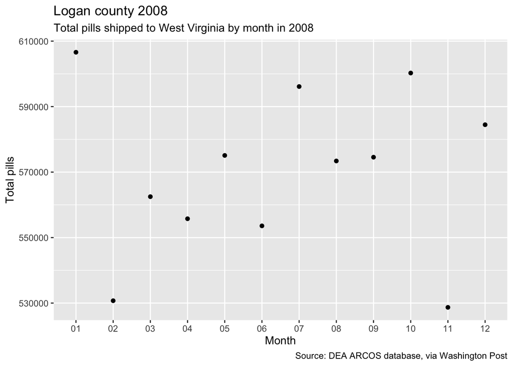

```r
west_virginia <- summarized_county_monthly(county="Logan", state="WV", key = key) %>%
clean_names()  %>%
filter(buyer_state == "WV", year=="2008")

ggplot(west_virginia) +
  geom_point(aes(month, dosage_unit)) +
  labs(x="Month", y="Total pills", title="Logan county 2008", subtitle = "Total pills shipped to West Virginia by month in 2008", caption = "Source: DEA ARCOS database, via Washington Post")
```

Year 2009

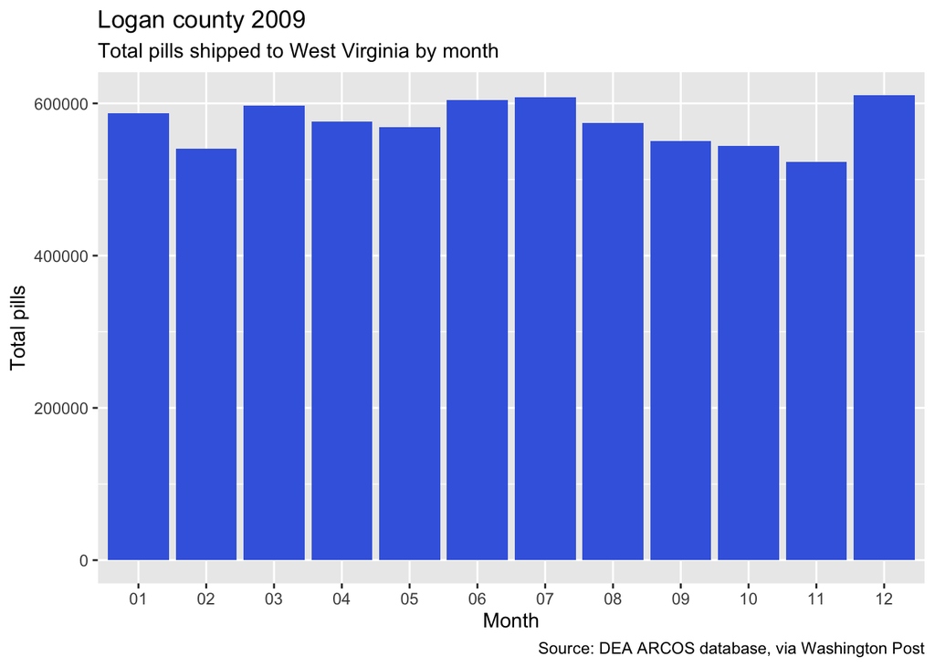

```r
west_virginia <- summarized_county_monthly(county="Logan", state="WV", key = key) %>%
clean_names()  %>%
filter(buyer_state == "WV", year=="2009")

ggplot(west_virginia) +
  geom_bar(stat="identity", aes(month, dosage_unit), fill="royal blue") +
  labs(x="Month", y="Total pills", title="Logan county 2009", subtitle = "Total pills shipped to West Virginia by month", caption = "Source: DEA ARCOS database, via Washington Post")
```

```r
  options(scipen=999)
```

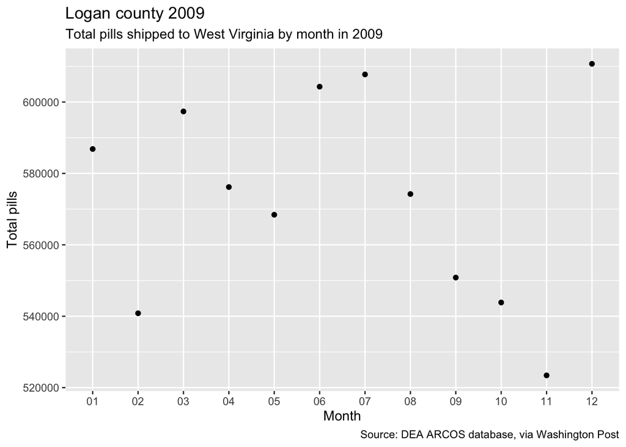

```r
west_virginia <- summarized_county_monthly(county="Logan", state="WV", key = key) %>%
clean_names()  %>%
filter(buyer_state == "WV", year=="2009")

ggplot(west_virginia) +
  geom_point(aes(month, dosage_unit)) +
 labs(x="Month", y="Total pills", title="Logan county 2009", subtitle = "Total pills shipped to West Virginia by month in 2009", caption = "Source: DEA ARCOS database, via Washington Post")
```

Year 2010

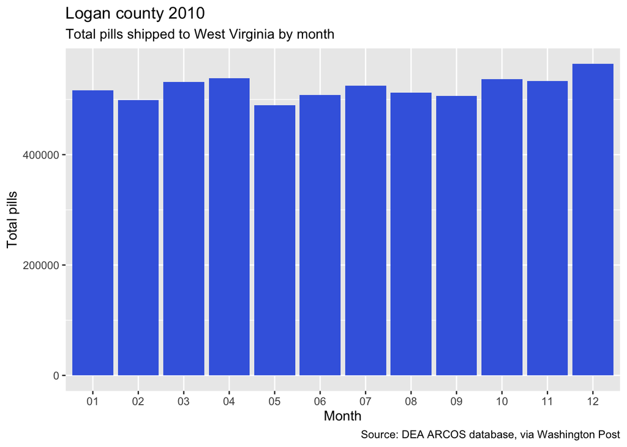

```r
west_virginia <- summarized_county_monthly(county="Logan", state="WV", key = key) %>%
clean_names()  %>%
filter(buyer_state == "WV", year=="2010")

ggplot(west_virginia) +
  geom_bar(stat="identity", aes(month, dosage_unit), fill="royal blue") +
  labs(x="Month", y="Total pills", title="Logan county 2010", subtitle = "Total pills shipped to West Virginia by month", caption = "Source: DEA ARCOS database, via Washington Post")
```

```r
  options(scipen=999)
```

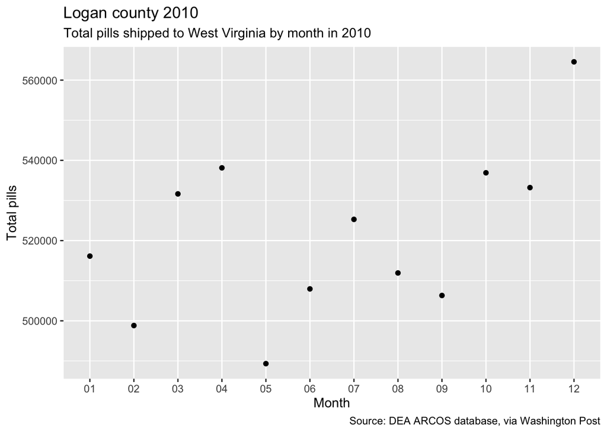

```r
west_virginia <- summarized_county_monthly(county="Logan", state="WV", key = key) %>%
clean_names()  %>%
filter(buyer_state == "WV", year=="2010")

ggplot(west_virginia) +
  geom_point(aes(month, dosage_unit)) +
  labs(x="Month", y="Total pills", title="Logan county 2010", subtitle = "Total pills shipped to West Virginia by month in 2010", caption = "Source: DEA ARCOS database, via Washington Post")
```

Year 2011

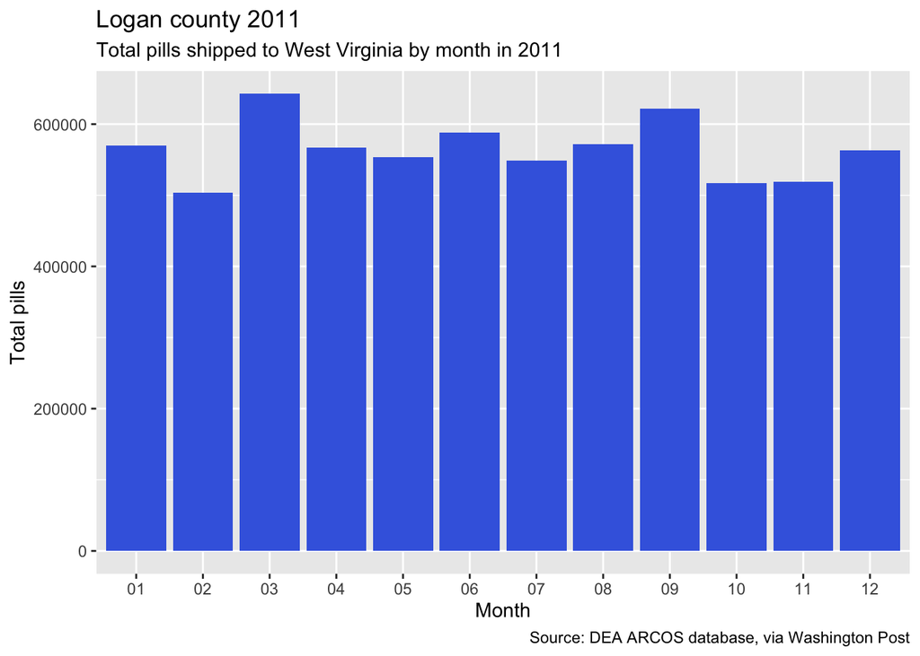

```r
west_virginia <- summarized_county_monthly(county="Logan", state="WV", key = key) %>%
clean_names()  %>%
filter(buyer_state == "WV", year=="2011")

ggplot(west_virginia) +
  geom_bar(stat="identity", aes(month, dosage_unit), fill="royal blue") +
  labs(x="Month", y="Total pills", title="Logan county 2011", subtitle = "Total pills shipped to West Virginia by month in 2011", caption = "Source: DEA ARCOS database, via Washington Post")
```

```r
options(scipen=999)
```

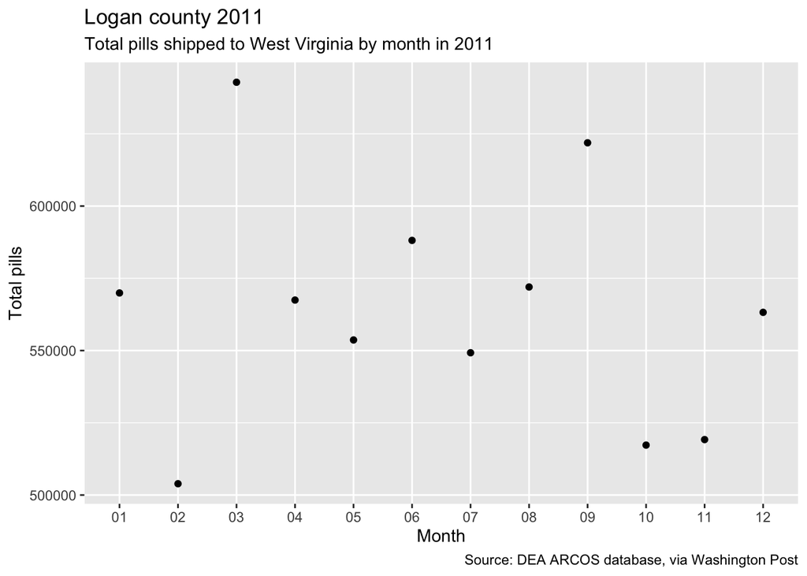

```r
west_virginia <- summarized_county_monthly(county="Logan", state="WV", key = key) %>%
clean_names()  %>%
filter(buyer_state == "WV", year=="2011")

ggplot(west_virginia) +
  geom_point(aes(month, dosage_unit)) +
 labs(x="Month", y="Total pills", title="Logan county 2011", subtitle = "Total pills shipped to West Virginia by month in 2011", caption = "Source: DEA ARCOS database, via Washington Post")
```

Year 2012

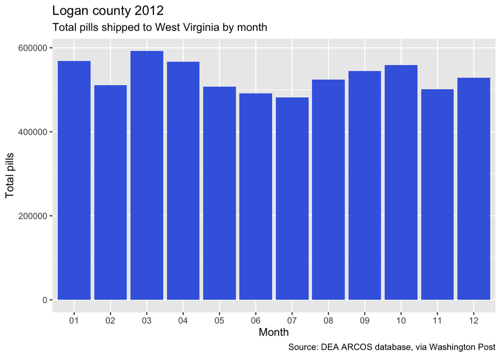

```r
west_virginia <- summarized_county_monthly(county="Logan", state="WV", key = key) %>%
clean_names()  %>%
filter(buyer_state == "WV", year=="2012")

ggplot(west_virginia) +
  geom_bar(stat="identity", aes(month, dosage_unit), fill="royal blue") +
  labs(x="Month", y="Total pills", title="Logan county 2012", subtitle = "Total pills shipped to West Virginia by month", caption = "Source: DEA ARCOS database, via Washington Post")
```

```r
  options(scipen=999)
```

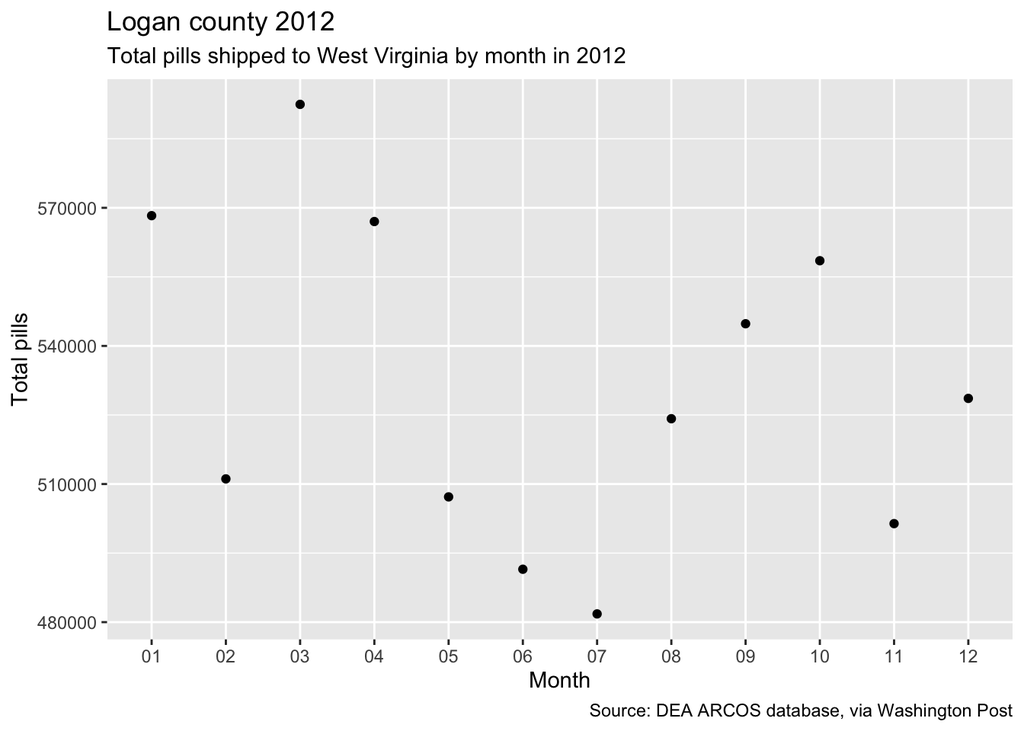

```r
west_virginia <- summarized_county_monthly(county="Logan", state="WV", key = key) %>%
clean_names()  %>%
filter(buyer_state == "WV", year=="2012")

ggplot(west_virginia) +
  geom_point(aes(month, dosage_unit)) +
  labs(x="Month", y="Total pills", title="Logan county 2012", subtitle = "Total pills shipped to West Virginia by month in 2012", caption = "Source: DEA ARCOS database, via Washington Post")
```

MINGO COUNTY, WEST VIRIGINIA ANALYSIS QUESTIONS

13. Do certain months consistently have more opioid shipments during the period of 2006-2012 relative to the other months?
14. Are there certain months that stay at a certain number of shipments consistently through-out the 2006 to 2012 period?
15. Do the winter months or the summer months have consistently more opioid shipments? If so in which years?
16. Is there a 12 month trend for opioid shipments that is consistent through-out the years 2006-2012?
17. Are there any abnormal or large spikes in the number of opioid shipments for a certain month?
18. (Conintinuation of last question) Are these spikes consitent in the month that it’s happening or is it a different month depending on the year?

PILLS BY MONTH FOR MINGO COUNTY, WEST VIRGINIA Year 2006

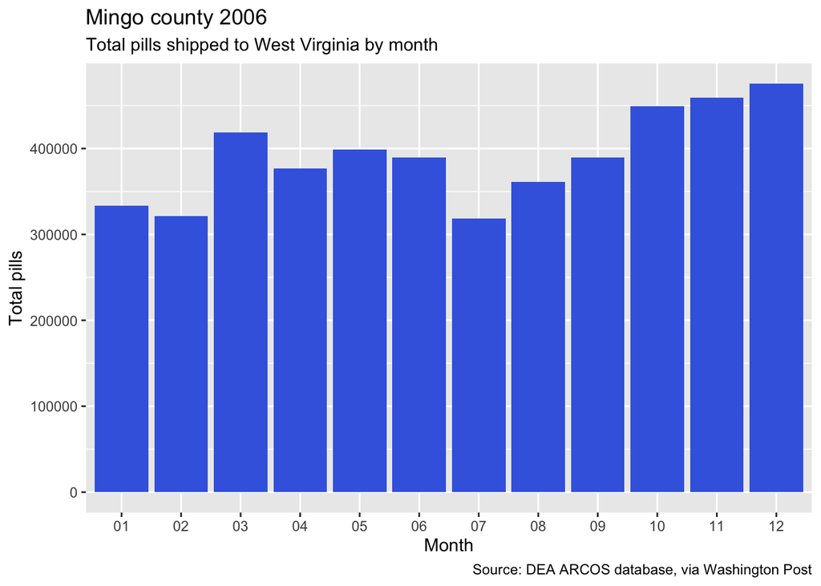

```r
west_virginia <- summarized_county_monthly(county="Mingo", state="WV", key = key) %>%
clean_names()  %>%
filter(buyer_state == "WV", year=="2006")

ggplot(west_virginia) +
  geom_bar(stat="identity", aes(month, dosage_unit), fill="royal blue") +
  labs(x="Month", y="Total pills", title="Mingo county 2006", subtitle = "Total pills shipped to West Virginia by month", caption = "Source: DEA ARCOS database, via Washington Post")
```

```r
  options(scipen=999)
```

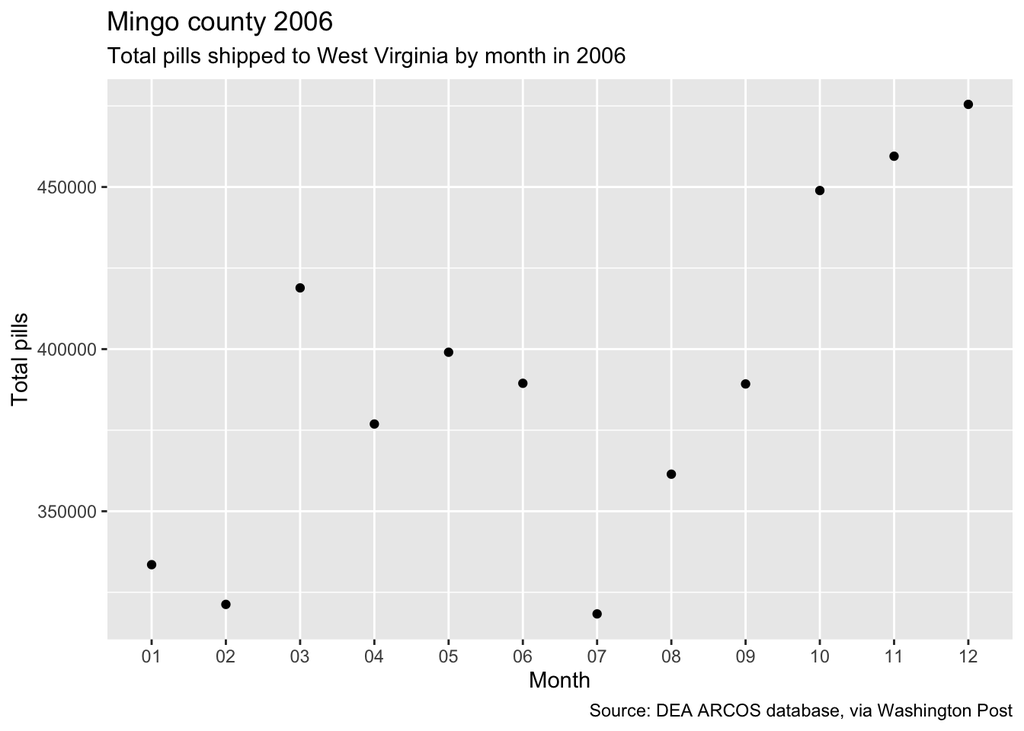

```r
west_virginia <- summarized_county_monthly(county="Mingo", state="WV", key = key) %>%
clean_names()  %>%
filter(buyer_state == "WV", year=="2006")

ggplot(west_virginia) +
  geom_point(aes(month, dosage_unit)) +
 labs(x="Month", y="Total pills", title="Mingo county 2006", subtitle = "Total pills shipped to West Virginia by month in 2006", caption = "Source: DEA ARCOS database, via Washington Post")
```

Year 2007

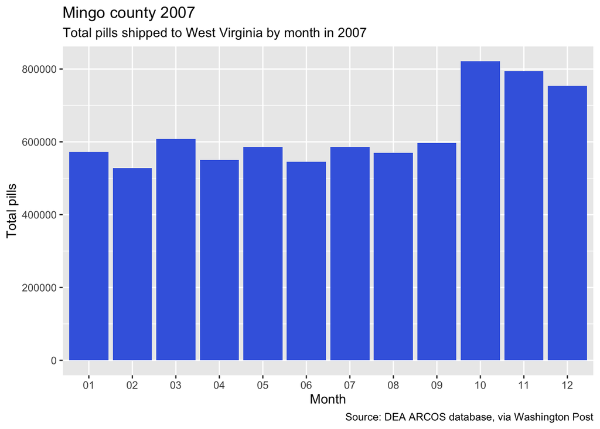

```r
west_virginia <- summarized_county_monthly(county="Mingo", state="WV", key = key) %>%
clean_names()  %>%
filter(buyer_state == "WV", year=="2007")

ggplot(west_virginia) +
  geom_bar(stat="identity", aes(month, dosage_unit), fill="royal blue") +
  labs(x="Month", y="Total pills", title="Mingo county 2007", subtitle = "Total pills shipped to West Virginia by month in 2007", caption = "Source: DEA ARCOS database, via Washington Post")
```

```r
  options(scipen=999)
```

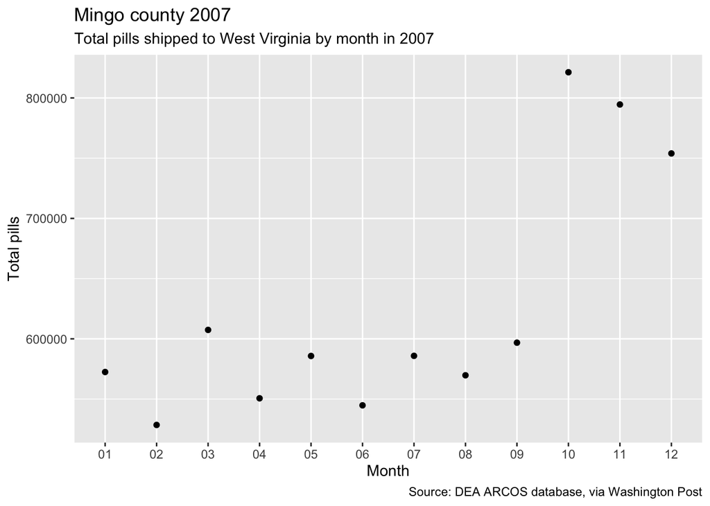

```r
west_virginia <- summarized_county_monthly(county="Mingo", state="WV", key = key) %>%
clean_names()  %>%
filter(buyer_state == "WV", year=="2007")

ggplot(west_virginia) +
  geom_point(aes(month, dosage_unit)) +
 labs(x="Month", y="Total pills", title="Mingo county 2007", subtitle = "Total pills shipped to West Virginia by month in 2007", caption = "Source: DEA ARCOS database, via Washington Post")
```

Year 2008

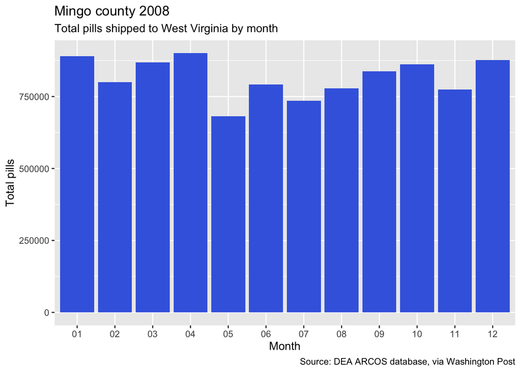

```r
west_virginia <- summarized_county_monthly(county="Mingo", state="WV", key = key) %>%
clean_names()  %>%
filter(buyer_state == "WV", year=="2008")

ggplot(west_virginia) +
  geom_bar(stat="identity", aes(month, dosage_unit), fill="royal blue") +
  labs(x="Month", y="Total pills", title="Mingo county 2008", subtitle = "Total pills shipped to West Virginia by month", caption = "Source: DEA ARCOS database, via Washington Post")
```

```r
  options(scipen=999)
```

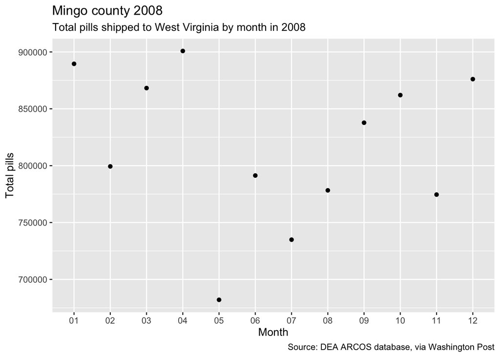

```r
west_virginia <- summarized_county_monthly(county="Mingo", state="WV", key = key) %>%
clean_names()  %>%
filter(buyer_state == "WV", year=="2008")

ggplot(west_virginia) +
  geom_point(aes(month, dosage_unit)) +
  labs(x="Month", y="Total pills", title="Mingo county 2008", subtitle = "Total pills shipped to West Virginia by month in 2008", caption = "Source: DEA ARCOS database, via Washington Post")
```

Year 2009

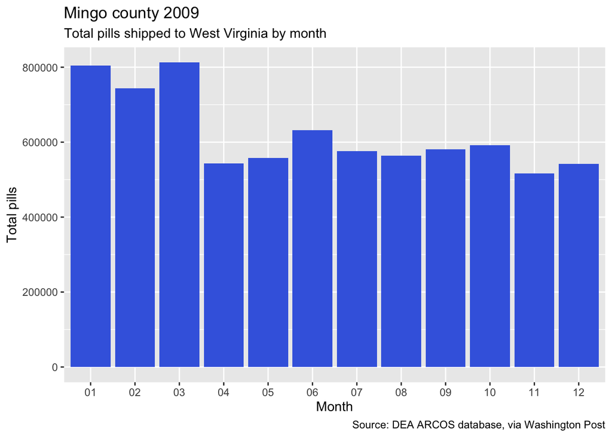

```r
west_virginia <- summarized_county_monthly(county="Mingo", state="WV", key = key) %>%
clean_names()  %>%
filter(buyer_state == "WV", year=="2009")

ggplot(west_virginia) +
  geom_bar(stat="identity", aes(month, dosage_unit), fill="royal blue") +
  labs(x="Month", y="Total pills", title="Mingo county 2009", subtitle = "Total pills shipped to West Virginia by month", caption = "Source: DEA ARCOS database, via Washington Post")
```

```r
  options(scipen=999)
```

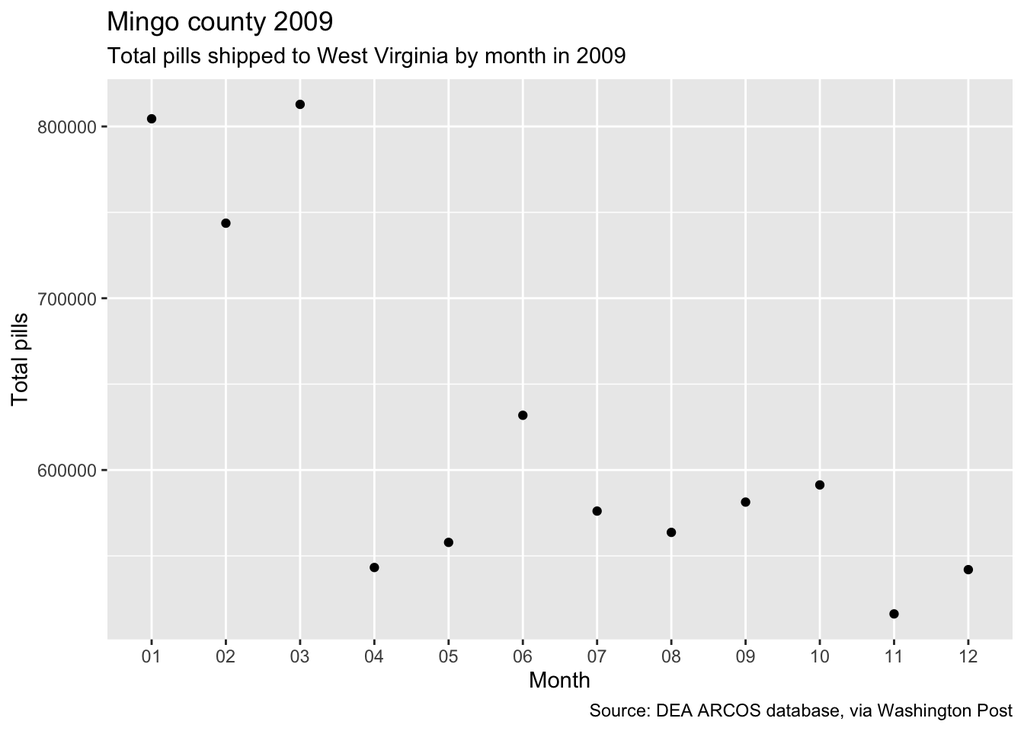

```r
west_virginia <- summarized_county_monthly(county="Mingo", state="WV", key = key) %>%
clean_names()  %>%
filter(buyer_state == "WV", year=="2009")

ggplot(west_virginia) +
  geom_point(aes(month, dosage_unit)) +
 labs(x="Month", y="Total pills", title="Mingo county 2009", subtitle = "Total pills shipped to West Virginia by month in 2009", caption = "Source: DEA ARCOS database, via Washington Post")
```

Year 2010

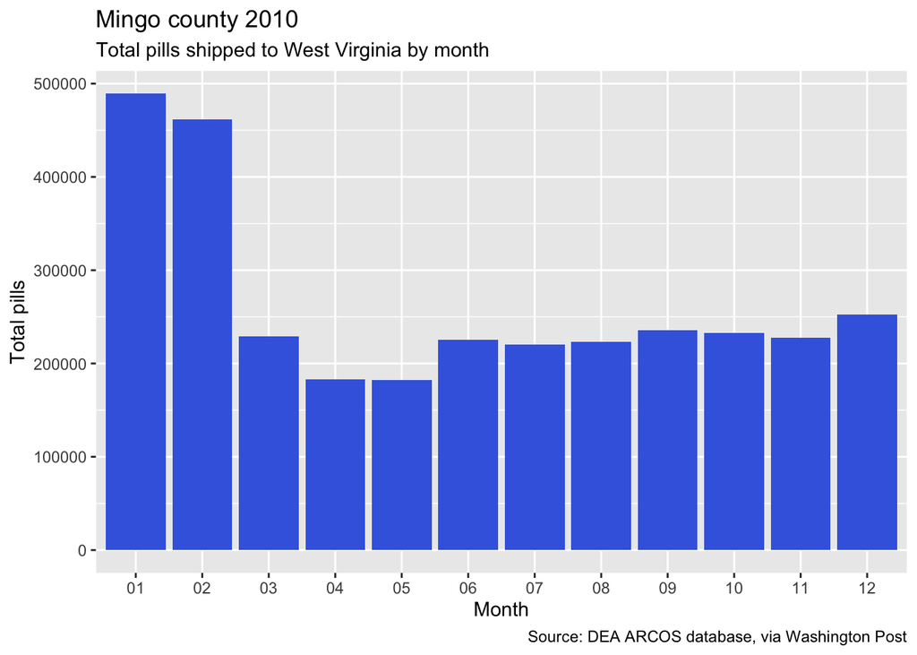

```r
west_virginia <- summarized_county_monthly(county="Mingo", state="WV", key = key) %>%
clean_names()  %>%
filter(buyer_state == "WV", year=="2010")

ggplot(west_virginia) +
  geom_bar(stat="identity", aes(month, dosage_unit), fill="royal blue") +
  labs(x="Month", y="Total pills", title="Mingo county 2010", subtitle = "Total pills shipped to West Virginia by month", caption = "Source: DEA ARCOS database, via Washington Post")
```

```r
  options(scipen=999)
```

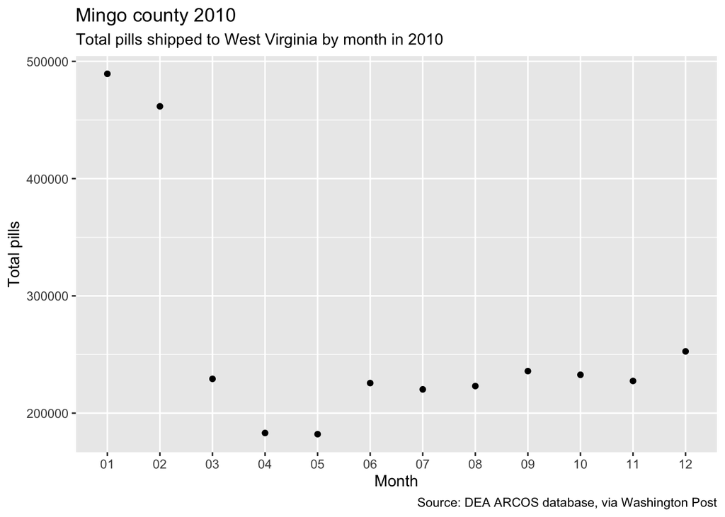

```r
west_virginia <- summarized_county_monthly(county="Mingo", state="WV", key = key) %>%
clean_names()  %>%
filter(buyer_state == "WV", year=="2010")

ggplot(west_virginia) +
  geom_point(aes(month, dosage_unit)) +
  labs(x="Month", y="Total pills", title="Mingo county 2010", subtitle = "Total pills shipped to West Virginia by month in 2010", caption = "Source: DEA ARCOS database, via Washington Post")
```

Year 2011

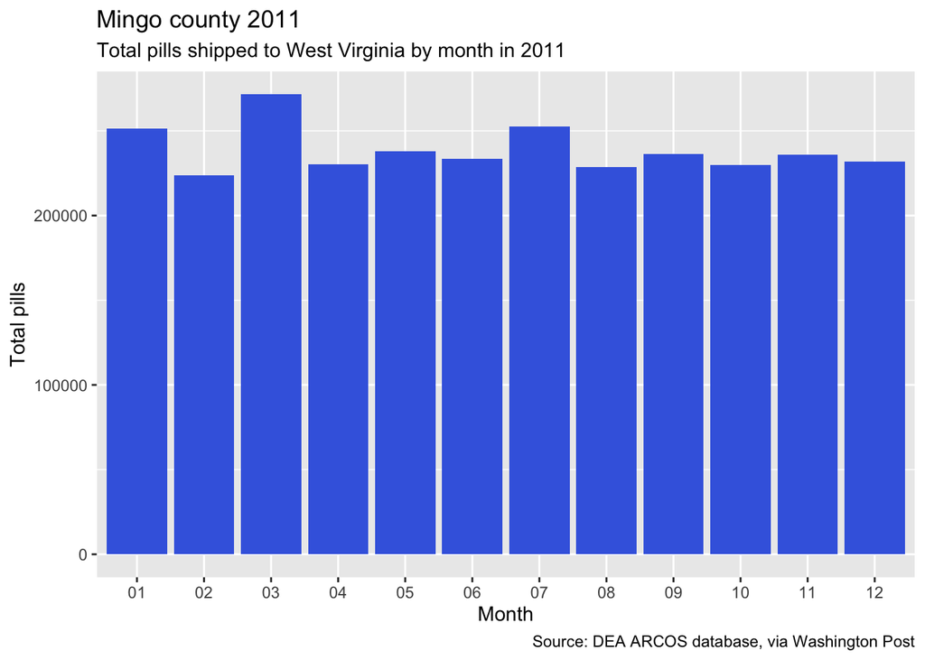

```r
west_virginia <- summarized_county_monthly(county="Mingo", state="WV", key = key) %>%
clean_names()  %>%
filter(buyer_state == "WV", year=="2011")

ggplot(west_virginia) +
  geom_bar(stat="identity", aes(month, dosage_unit), fill="royal blue") +
  labs(x="Month", y="Total pills", title="Mingo county 2011", subtitle = "Total pills shipped to West Virginia by month in 2011", caption = "Source: DEA ARCOS database, via Washington Post")
```